# *MULTISCALE ANALYSES ON ARTERIOVENOUS FISTULA MATURATION*

Rosamaria Tricarico

February 1, 2018

**PROJECT OUTLINE**

Arteriovenous fistula for hemodialysis access fails to clinically mature in [28-53%](https://cjasn.asnjournals.org/content/clinjasn/1/2/332.full.pdf) of the cases.

My goal is to identify inter-correlations among time-changes in fistula morphology, hemodynamics, gene expression, and smooth muscle cell and endothelial cell dysfunctions. These results can play a fundamental role in the understating of fistula maturation and failure causes, influencing clinical techniques as well as innovative strategies for fistula maturation.

**BACKGROUND**

Over 650,000 Americans are affected by [end stage renal disease](https://www.niddk.nih.gov/health-information/health-statistics/kidney-disease), which requires [hemodialysis treatment](https://www.niddk.nih.gov/health-information/kidney-disease/kidney-failure/hemodialysis) until availability for kidney transplant. [Arteriovenous fistula](https://surgery.ucsf.edu/conditions--procedures/vascular-access-for-hemodialysis.aspx), a surgical connection between artery and vein of the arm, is recognized as the best hemodialysis access, as it has been reported to have lower thrombosis and infection rates compared to other fistulas. However, obtaining clinically mature fistula is challenging and the causes of fistula maturation failures are unknown. [Research investigations](https://pubs.rsna.org/doi/pdf/10.1148/radiol.2015150385) are being performed to gain an insight into the mechanisms of maturation failure, from vascular anatomy and hemodynamics, to cell dysfunction and genomics that might play a role in vascular maturation, yet among the major limitations are small data-sets and lack of interconnection among events at micro- and macro-scales.

The [Division of Vascular Surgery at the University of Florida Shands Hospital](https://vascular.surgery.med.ufl.edu/research/national-institutes-of-health-study-of-av-fistulas/) has dedicated over 8 years on multiscale analyses on arteriovenous fistula maturation placing itself among the top six internationally recognized centers specialized on the topic. This vaste research has generated large patient-specific data-sets, now available for data science exploration.

**DATA-SETS**

The data-sets are composed by:

1. **Gene expression of monocytes and neutrophils (53,662 total) on 50 patients at two time points (baseline, 2 weeks).**  
   Scientific reasoning: circulating leukocytes (such as monocytes and neutrophils) play a role in development of intimal hyperplasia. Monocytes and neutrophils both exhibit phenotype plasticity that is associated with either pro-inflammatory or non-inflammatory states. Dynamic gene expression would give insight into their role during arteriovenous fistula adaption; unique responses might occur between fistulas that successfully mature and those that don’t.  
   RNA was isolated and expression levels were determined using microarrays.
2. **Anatomic and hemodynamic data along the fistula length of 50 patients at 3 time points (baseline, 6 weeks, 6 months).**  
   Scientific reasoning: fistula maturation consists of vessel adaptation to larger blood flow. For instance, the venous and arterial diameter increase and the vessel undergo structural change to withstand higher blood flow. If vascular adaptation mechanism fails, larger wall-shear stresses (WSS), wall-shear stress gradients (WSSG), and oscillatory shear index (OSI) can be observed. Anatomic data was extracted from ultrasound imaging; hemodynamic data was extracted from patient-specific computational fluid-dynamic analyses.
3. **Brachial artery dilation on 50 patients at two time points (pre- and post-fistula).**  
   Scientific reasoning: Also endothelial and smooth muscle cells play a role in vessel wall adaption to stimuli. Flow-mediated and nitroglycerin-mediated dilation (FMD and NMD, respectively) are utilized for non-invasive assessment of endothelium-dependent and endothelium-independent (smooth muscle cell) vessel functions. Dilation is measured with ultrasound imaging. *The results related to this data-set are not be presented in this notebook.*

**EXPLORATORY ANALYSES**

We will first have an overview of the full anatomic-hemodyamic and genomic data-sets to undestand their major characteristics and distributions.

*1. GENOMICS*

|  | Gene | log2FoldChange | pvalue |
| --- | --- | --- | --- |
| 1 | OR4F5 | -0.091926756757 | 0.02442975969 |
| 2 | FAM87B | 0.006987432432 | 0.77310683917 |
| 3 | SAMD11 | -0.065901621622 | 0.07855414172 |
| 4 | KLHL17 | -0.057498243243 | 0.10464536062 |
| 5 | PLEKHN1 | -0.047027972973 | 0.16463621199 |
| 6 | ISG15 | 0.010980810811 | 0.81676479783 |

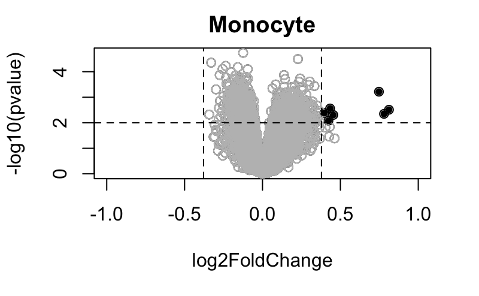

The genes with larger expression variation are listed below. The total number of significant genes from monocytes is equal to 7.

|  | Gene | log2FoldChange | pvalue |
| --- | --- | --- | --- |
| 7900 | ALAS2 | 0.7476359459 | 0.0006071577216 |
| 13151 | SLC4A1 | 0.4339390541 | 0.0027494050328 |
| 16609 | SNORA16B | 0.4237432432 | 0.0083090947445 |
| 18990 | LOC100303749 | 0.4547874324 | 0.0049421246366 |
| 21688 | IFIT1B | 0.8119282432 | 0.0030909694014 |
| 23837 | MIR626 | 0.3975659459 | 0.0041431498863 |
| 24219 | AHSP | 0.7802017568 | 0.0044816941880 |

*NEUTROPHILS*: I replicated the same approach for neutrophil gene expression.

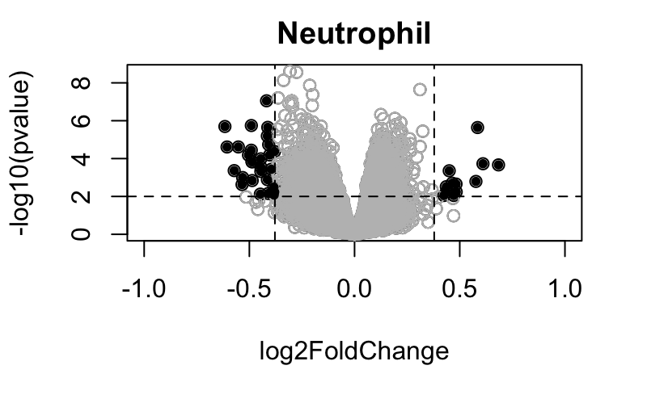

The genes with larger expression variation are listed below. The total number of significant genes from neutrophils is equal to 42.

|  | Gene | log2FoldChange | pvalue |
| --- | --- | --- | --- |
| 348 | MIR1244-1 | -0.4871089583 | 0.00014777587405632 |
| 399 | SNORA14B | 0.4499304167 | 0.00044078120371169 |
| 859 | RNU5E-2P | -0.5319514583 | 0.00100251859276439 |
| 1850 | MIR101-1 | -0.3859233333 | 0.00765206180627648 |
| 2514 | PLIN2 | -0.4457712500 | 0.00010299324467910 |
| 2537 | RANP1 | -0.4032514583 | 0.00006448046379633 |
| 2908 | MIR3662 | -0.4909233333 | 0.00003609397587910 |
| 3088 | RPL13AP20 | -0.4905575000 | 0.00000179656184201 |
| 3498 | GPR82 | -0.3822110417 | 0.00836101332853492 |
| 3506 | SNORA20 | 0.4823210417 | 0.00221565478546430 |

[output cut: 32 more lines]

Let’s move to the anatomic-hemodynamic data-set.

*2. VESSELS’ MORPHOLOGY AND HEMODYNAMICS*

*VEIN*: the full anatomic and hemodynamic data-set of the *venous* portion of the fistula is displayed below.

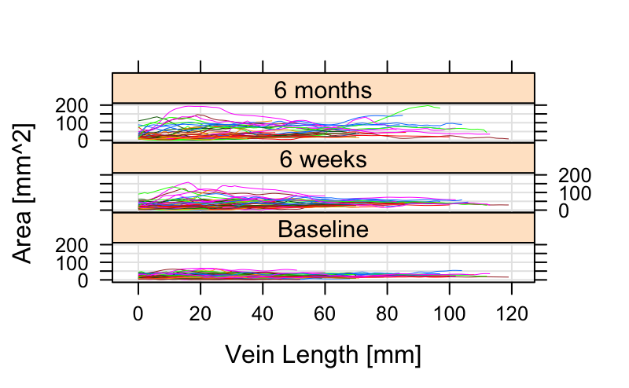

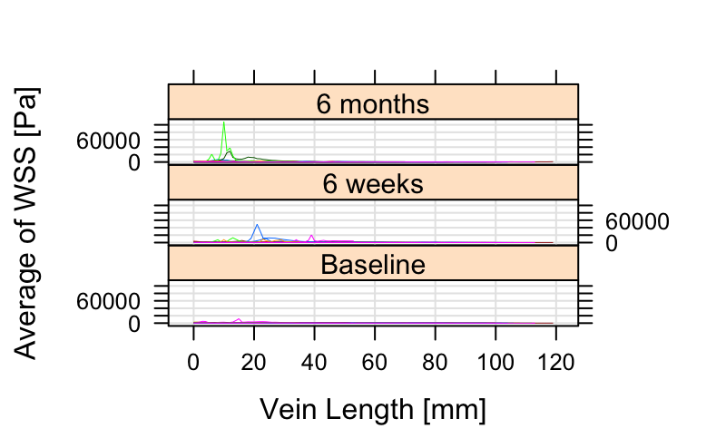

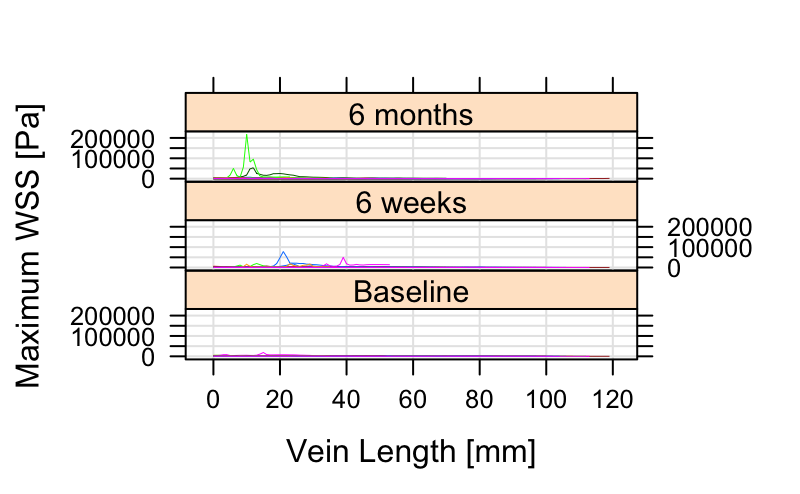

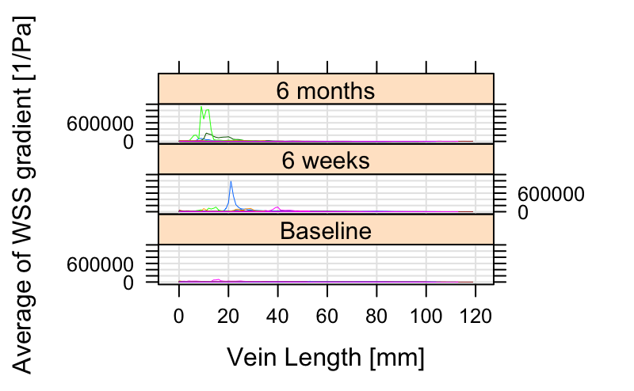

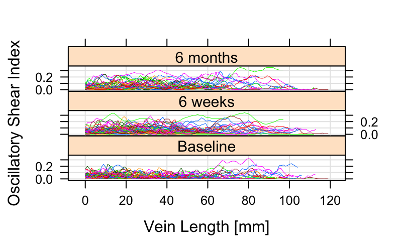

*ARTERY*: an overview of the full anatomic and hemodynamic data-set follows for *arterial* portion of the fistula.

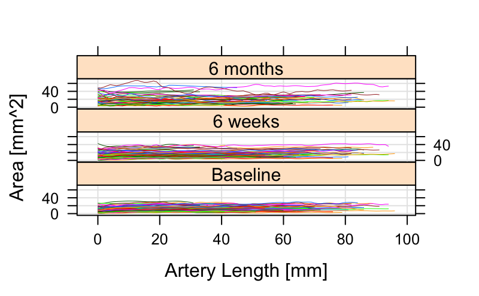

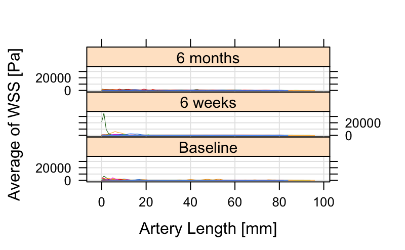

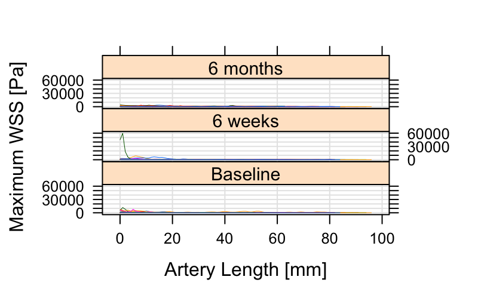

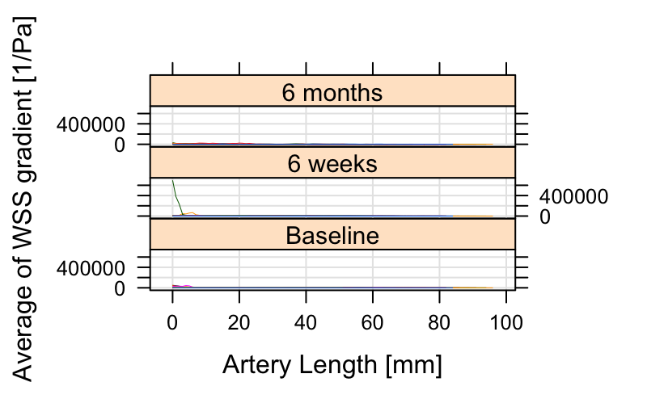

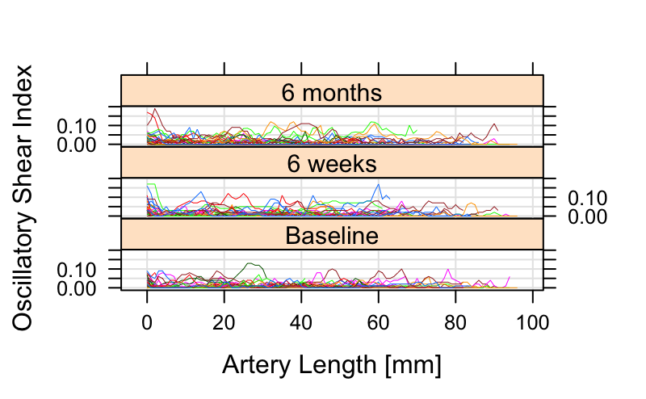

As the *vein anatomy and hemodynamics* undergo to the largest changes, most visible from the area graphs, for the purposes of this brief presentation, from now on we will focus *vein* investigation.

*Moving to the next phase of the epxloratory analysis, we will dive in our data-sets in more depth.* *By investigating the anatomy and hemodynamics on a patient-specific basis and compare it with the patient-specific genomic results, we can obtain a list of genes that are potentially involved with fistula remodelling and/or maturation failure mechanics.* *Aim: identify whether unique responses occur for fistulas that successfully mature and those that don’t.*

*3. PATIENT 1 - MORPHOLOGY AND HEMODYNAMICS*

[figure not shown]

For this reason, next we analyze the genomic of this patient to identify genes that might be involved in fistula maturation failure.

*4. PATIENT 1 - GENOMICS*

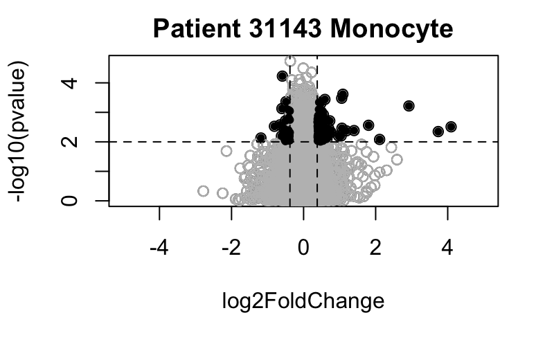

The list of significant change in gene expression from *monocytes* is here reported. Total number 124.

|  | Gene | log2FoldChange | pvalue |
| --- | --- | --- | --- |
| 168 | EPB41 | 0.43352 | 0.00224551571222 |
| 665 | RGS13 | 0.55061 | 0.00709205454246 |
| 728 | TRAF5 | -0.38086 | 0.00897328953926 |
| 1015 | MRPS15 | 0.38673 | 0.00603440395077 |
| 1188 | SORT1 | -0.38826 | 0.00606905520190 |
| 1510 | YOD1 | 0.69822 | 0.00356528651780 |
| 1761 | C2orf56 | 0.50993 | 0.00867963283983 |
| 1847 | VAMP8 | 0.39101 | 0.00629089707431 |
| 2044 | PLCL1 | -0.51230 | 0.00706946971325 |
| 2511 | TRAK2 | 0.54961 | 0.00394979476998 |

[output cut: 114 more lines]

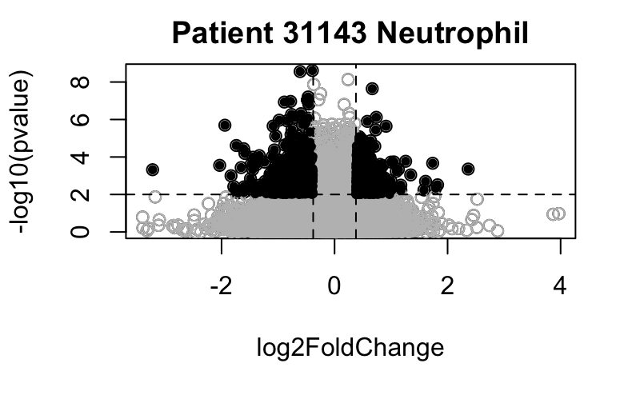

|  | Gene | log2FoldChange | pvalue |
| --- | --- | --- | --- |
| 36 | LDLRAD2 | 0.50478 | 0.000391757198826897 |
| 57 | RN5S60 | -0.54672 | 0.000259611908792040 |
| 79 | BRI3BP | -0.80163 | 0.000403016547413653 |
| 97 | CECR2 | 0.38770 | 0.001799342358980810 |
| 134 | LOC100506767 | 0.38132 | 0.001988084188099170 |
| 173 | DISP2 | 0.40196 | 0.004452075679691940 |
| 217 | RN5S40 | 0.38977 | 0.000140416354497289 |
| 300 | HLA-DRA | -1.06073 | 0.007053603790545860 |
| 322 | C1QA | 0.58987 | 0.001407759878247790 |
| 336 | CMA1 | 0.80372 | 0.000248718708042324 |

[output cut: 990 more lines]

*By investigating the genomics of all patients which fistula already failied or show hemodynamic signatures of failure, we are able to obtain a list of genes potenitally involved with fistula failure mechanicsms.*

**Full data-sets can be found [here](https://github.com/RosamariaTricarico/2019TDI/tree/master/DATA.SETS).**  
**Main R scripts can be found [here](https://github.com/RosamariaTricarico/2019TDI/tree/master/R.SCRIPTS).**